# Qualitative Activity Recognition of Weight Lifting Exercises

Frank Inklaar

11 februari 2019

# Synopis

In this asigment we aim to predict whether a physical excercise (Unilateral Dumbbell Biceps Curl) has been performed correctly or whether a well know mistake has been made. We have a training set created by recording the activities of 6 individuals each performing the excercise correctly and performing the excercise with one out of four known mistakes in sequence. Each recording has been labled with a ‘class’ variable where ‘A’ is the correct way of performing the excercise and ‘B’ through ‘E’ are the erroneous ways. Each excercise was recorded by 4 sensors attached to upper arm, wrist, waist and the dumbbell respectedly. Each sensor is measuring acceleration in three dimensions as well as rotation in three dimensional axes. We aim to train a model that can predict from each measurement to what ‘classe’ it belongs. With this model we would be able to provide real time feedback to the individual performing the excercise.

# Data processing

## Loading the data

We load the data. We suppress the immidiate conversion to factors as it seems to have some unwanted effect on this dataset. We’ll convert the right columns to factor variables later on.

```r
set.seed(12345)
training<-read.csv("pml-training.csv",stringsAsFactors = FALSE)
testing<-read.csv("pml-testing.csv",stringsAsFactors = FALSE)
```

## Exploring the data

As a first step, let’s get some very basic info about the dataset we’ve just read

```r
print(dim(training))
```

```
## [1] 19622   160
```

```r
head(training)
```

```
##   X user_name raw_timestamp_part_1 raw_timestamp_part_2   cvtd_timestamp
## 1 1  carlitos           1323084231               788290 05/12/2011 11:23
## 2 2  carlitos           1323084231               808298 05/12/2011 11:23
## 3 3  carlitos           1323084231               820366 05/12/2011 11:23
## 4 4  carlitos           1323084232               120339 05/12/2011 11:23
## 5 5  carlitos           1323084232               196328 05/12/2011 11:23
## 6 6  carlitos           1323084232               304277 05/12/2011 11:23
##   new_window num_window roll_belt pitch_belt yaw_belt total_accel_belt
## 1         no         11      1.41       8.07    -94.4                3
## 2         no         11      1.41       8.07    -94.4                3
## 3         no         11      1.42       8.07    -94.4                3
## 4         no         12      1.48       8.05    -94.4                3
## 5         no         12      1.48       8.07    -94.4                3
## 6         no         12      1.45       8.06    -94.4                3
##   kurtosis_roll_belt kurtosis_picth_belt kurtosis_yaw_belt
```

[output cut: 265 more lines]

From the first check it’s obvious that not all colums seem to contain data. Further inspection reveals that the dataset contains two distinct kind of rows. The records labeled new_window = ‘no’ contain only raw data from the sensors, while the records labeled ‘yes’ also contain statistical derivatives from one complete excersize.

```r
# check how a 'statistical' column relates tot the 'new_window' variable
print(table(training$new_window,training$kurtosis_roll_belt==""))
```

```
##
##       FALSE  TRUE
##   no      0 19216
##   yes   406     0
```

```r
# check if the test set contains any 'new_window' rows
print(table(testing$new_window))
```

```
##
## no
## 20
```

Since the test set contains only records where new_window = ‘no’ we cannot use this information in our prediction. For this reason we will get rid of the columns that only have information for the ‘yes’ records. We will also get rid of the timestamp information, as this would result in recognizing ‘when’ the activity was performed rather than ‘how’.

## Cleaning the Data

Since the test set has only new_window = “no” records we can kick the “yes” records out of the training set and after that, get rid of all the columns that have a constant value or all NA’s

```r
training<-training[training$new_window=="no",]

na_cols<-which(colSums(is.na(training))==nrow(training))

blank_cols<-which(colSums(training[,]=="")==nrow(training))

training<-training[,c(-na_cols,-blank_cols)]
testing<-testing[,c(-na_cols,-blank_cols)]

#convert uses_name and classe to factor variables
training$user_name<-factor(training$user_name)
testing$user_name<-factor(testing$user_name,levels=levels(training$user_name))
training$classe<-factor(training$classe)

#get rid of all timestamp related columns
training$X<-NULL; testing$X<-NULL
training$raw_timestamp_part_1<-NULL; testing$raw_timestamp_part_1<-NULL
training$raw_timestamp_part_2<-NULL; testing$raw_timestamp_part_2<-NULL
training$cvtd_timestamp<-NULL; testing$cvtd_timestamp<-NULL
training$new_window<-NULL; testing$new_window<-NULL
training$num_window<-NULL; testing$num_window<-NULL
```

Finally, exploratory data analyses shows that there are some outliers. For instance if we look at the gyros_forearm_z column:

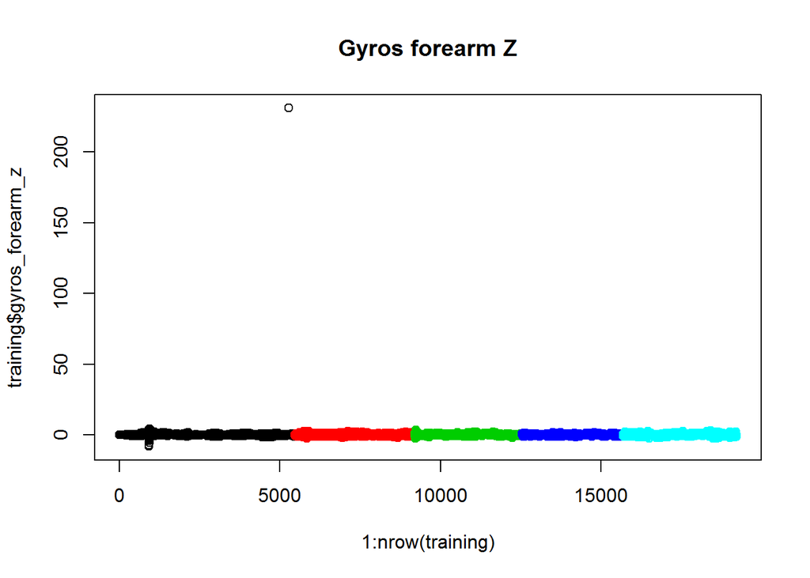

```r
plot(1:nrow(training),training$gyros_forearm_z,col=training$classe); title("Gyros forearm Z")
```

```r
which(training$gyros_forearm_z>200)
```

```
## [1] 5270
```

```r
#record 5270 is an outlier, get rid of it
training<-training[-5270,]
```

# Training the model

## Model selection

From the nature of this experiment, it seems probable that the classification result will not have a linear dependency of the sensor outputs. For this case a Random Forest seem to be a proper model. We’ll train a Random Forest model with 5 fold cross validation to get a predicited value for our out of set prediction error.

## Training the model

First we load the nescessary libraries and set up the laptop for multithreading to reduce run time.

```r
library(caret)
library(parallel)
library(doParallel)
library(beepr)
cluster <- makeCluster(detectCores() - 1) # convention to leave 1 core for OS
registerDoParallel(cluster)
```

Now train the model with 5 fold cross validation

```r
fitControl <- trainControl(method = "cv",
                           number = 5,
                           allowParallel = TRUE)
fit <- caret::train(classe~.-user_name, method="rf",data=training,trControl = fitControl)
beep()
```

And check the results:

```r
print(fit)
```

```
## Random Forest
##
## 19215 samples
##    53 predictor
##     5 classes: 'A', 'B', 'C', 'D', 'E'
##
## No pre-processing
## Resampling: Cross-Validated (5 fold)
## Summary of sample sizes: 15373, 15373, 15371, 15371, 15372
## Resampling results across tuning parameters:
##
##   mtry  Accuracy   Kappa
##    2    0.9940152  0.9924284
##   27    0.9941191  0.9925600
##   52    0.9889672  0.9860421
##
## Accuracy was used to select the optimal model using the largest value.
## The final value used for the model was mtry = 27.
```

```r
print(fit$resample)
```

```
##    Accuracy     Kappa Resample
## 1 0.9927121 0.9907794    Fold1
## 2 0.9927159 0.9907840    Fold3
## 3 0.9945341 0.9930851    Fold2
## 4 0.9950559 0.9937456    Fold5
## 5 0.9955775 0.9944056    Fold4
```

```r
print(confusionMatrix.train(fit))
```

```
## Cross-Validated (5 fold) Confusion Matrix
##
## (entries are percentual average cell counts across resamples)
##
##           Reference
## Prediction    A    B    C    D    E
##          A 28.4  0.1  0.0  0.0  0.0
##          B  0.0 19.2  0.1  0.0  0.0
##          C  0.0  0.0 17.3  0.2  0.0
##          D  0.0  0.0  0.1 16.2  0.0
##          E  0.0  0.0  0.0  0.0 18.3
##
##  Accuracy (average) : 0.9941
```

The results are good, showing that results can be predicted with over 99% accurancy

## Applying the final model to the test set

Finally we make predictions to the test set. For this case, we retrain the model over the entire training set to get a slighty higher reliability. We train the model and check the results

```r
fitControl <- trainControl(method = "boot",
                           number = 1,
                           allowParallel = TRUE)

fitFinal <- train(classe~., method="rf",data=training,trControl = fitControl)
beep()
fitFinal
```

```
## Random Forest
##
## 19215 samples
##    53 predictor
##     5 classes: 'A', 'B', 'C', 'D', 'E'
##
## No pre-processing
## Resampling: Bootstrapped (1 reps)
## Summary of sample sizes: 19215
## Resampling results across tuning parameters:
##
##   mtry  Accuracy   Kappa
##    2    0.9938668  0.9922353
##   29    0.9920126  0.9898890
##   57    0.9833119  0.9788757
##
## Accuracy was used to select the optimal model using the largest value.
## The final value used for the model was mtry = 2.
```

Predict on the test set:

```r
testpredict<-predict(fitFinal,newdata = testing)
testpredict
```

```
##  [1] B A B A A E D B A A B C B A E E A B B B
## Levels: A B C D E
```

(Don’t forget to close the multithreading)

```r
stopCluster(cluster)
registerDoSEQ()
```